# Risk Factor Analysis

## Outcome Variable

**Outcome Variable:** stunted

## Predictor Variables

**Intervention Variable:** mbmi

**Adjustment Set:**

- arm
- W_mage
- W_fage
- meducyrs
- feducyrs
- single
- brthmon
- delta_W_mage
- delta_W_fage
- delta_meducyrs
- delta_feducyrs
- delta_single
- delta_brthmon

## Stratifying Variables

The analysis was stratified on these variable(s):

- agecat
- studyid
- country

## Data Summary

| agecat | studyid | country | mbmi | stunted | n_cell | n |
| --- | --- | --- | --- | --- | --- | --- |
| Birth | ki0047075b-MAL-ED | BANGLADESH | [18.5-25) | 0 | 130 | 246 |
| Birth | ki0047075b-MAL-ED | BANGLADESH | [18.5-25) | 1 | 28 | 246 |
| Birth | ki0047075b-MAL-ED | BANGLADESH | <18.5 | 0 | 25 | 246 |
| Birth | ki0047075b-MAL-ED | BANGLADESH | <18.5 | 1 | 5 | 246 |
| Birth | ki0047075b-MAL-ED | BANGLADESH | [25-30) | 0 | 47 | 246 |
| Birth | ki0047075b-MAL-ED | BANGLADESH | [25-30) | 1 | 5 | 246 |
| Birth | ki0047075b-MAL-ED | BANGLADESH | >=30 | 0 | 2 | 246 |
| Birth | ki0047075b-MAL-ED | BANGLADESH | >=30 | 1 | 4 | 246 |
| 6 months | ki0047075b-MAL-ED | BANGLADESH | [18.5-25) | 0 | 124 | 241 |
| 6 months | ki0047075b-MAL-ED | BANGLADESH | [18.5-25) | 1 | 29 | 241 |
| 6 months | ki0047075b-MAL-ED | BANGLADESH | <18.5 | 0 | 22 | 241 |
| 6 months | ki0047075b-MAL-ED | BANGLADESH | <18.5 | 1 | 10 | 241 |
| 6 months | ki0047075b-MAL-ED | BANGLADESH | [25-30) | 0 | 48 | 241 |
| 6 months | ki0047075b-MAL-ED | BANGLADESH | [25-30) | 1 | 2 | 241 |
| 6 months | ki0047075b-MAL-ED | BANGLADESH | >=30 | 0 | 2 | 241 |
| 6 months | ki0047075b-MAL-ED | BANGLADESH | >=30 | 1 | 4 | 241 |
| 24 months | ki0047075b-MAL-ED | BANGLADESH | [18.5-25) | 0 | 69 | 212 |
| 24 months | ki0047075b-MAL-ED | BANGLADESH | [18.5-25) | 1 | 65 | 212 |
| 24 months | ki0047075b-MAL-ED | BANGLADESH | <18.5 | 0 | 10 | 212 |
| 24 months | ki0047075b-MAL-ED | BANGLADESH | <18.5 | 1 | 19 | 212 |
| 24 months | ki0047075b-MAL-ED | BANGLADESH | [25-30) | 0 | 34 | 212 |
| 24 months | ki0047075b-MAL-ED | BANGLADESH | [25-30) | 1 | 11 | 212 |
| 24 months | ki0047075b-MAL-ED | BANGLADESH | >=30 | 0 | 1 | 212 |
| 24 months | ki0047075b-MAL-ED | BANGLADESH | >=30 | 1 | 3 | 212 |
| Birth | ki0047075b-MAL-ED | BRAZIL | [18.5-25) | 0 | 62 | 184 |
| Birth | ki0047075b-MAL-ED | BRAZIL | [18.5-25) | 1 | 8 | 184 |
| Birth | ki0047075b-MAL-ED | BRAZIL | <18.5 | 0 | 7 | 184 |
| Birth | ki0047075b-MAL-ED | BRAZIL | <18.5 | 1 | 2 | 184 |
| Birth | ki0047075b-MAL-ED | BRAZIL | [25-30) | 0 | 62 | 184 |
| Birth | ki0047075b-MAL-ED | BRAZIL | [25-30) | 1 | 7 | 184 |

[output cut: 284 more lines]

The following strata were considered:

- agecat: 24 months, studyid: ki0047075b-MAL-ED, country: BANGLADESH
- agecat: 24 months, studyid: ki0047075b-MAL-ED, country: BRAZIL
- agecat: 24 months, studyid: ki0047075b-MAL-ED, country: INDIA
- agecat: 24 months, studyid: ki0047075b-MAL-ED, country: NEPAL
- agecat: 24 months, studyid: ki0047075b-MAL-ED, country: PERU
- agecat: 24 months, studyid: ki0047075b-MAL-ED, country: SOUTH AFRICA
- agecat: 24 months, studyid: ki0047075b-MAL-ED, country: TANZANIA, UNITED REPUBLIC OF
- agecat: 24 months, studyid: ki1017093-NIH-Birth, country: BANGLADESH
- agecat: 24 months, studyid: ki1017093b-PROVIDE, country: BANGLADESH
- agecat: 24 months, studyid: ki1017093c-NIH-Crypto, country: BANGLADESH
- agecat: 24 months, studyid: ki1066203-TanzaniaChild2, country: TANZANIA, UNITED REPUBLIC OF
- agecat: 24 months, studyid: ki1119695-PROBIT, country: BELARUS
- agecat: 24 months, studyid: ki1126311-ZVITAMBO, country: ZIMBABWE
- agecat: 24 months, studyid: ki1148112-LCNI-5, country: MALAWI
- agecat: 6 months, studyid: ki0047075b-MAL-ED, country: BANGLADESH
- agecat: 6 months, studyid: ki0047075b-MAL-ED, country: BRAZIL
- agecat: 6 months, studyid: ki0047075b-MAL-ED, country: INDIA
- agecat: 6 months, studyid: ki0047075b-MAL-ED, country: NEPAL
- agecat: 6 months, studyid: ki0047075b-MAL-ED, country: PERU
- agecat: 6 months, studyid: ki0047075b-MAL-ED, country: SOUTH AFRICA
- agecat: 6 months, studyid: ki0047075b-MAL-ED, country: TANZANIA, UNITED REPUBLIC OF
- agecat: 6 months, studyid: ki1000304b-SAS-CompFeed, country: INDIA
- agecat: 6 months, studyid: ki1017093-NIH-Birth, country: BANGLADESH
- agecat: 6 months, studyid: ki1017093b-PROVIDE, country: BANGLADESH
- agecat: 6 months, studyid: ki1017093c-NIH-Crypto, country: BANGLADESH
- agecat: 6 months, studyid: ki1066203-TanzaniaChild2, country: TANZANIA, UNITED REPUBLIC OF
- agecat: 6 months, studyid: ki1119695-PROBIT, country: BELARUS
- agecat: 6 months, studyid: ki1126311-ZVITAMBO, country: ZIMBABWE
- agecat: 6 months, studyid: ki1148112-LCNI-5, country: MALAWI
- agecat: Birth, studyid: ki0047075b-MAL-ED, country: BANGLADESH
- agecat: Birth, studyid: ki0047075b-MAL-ED, country: BRAZIL
- agecat: Birth, studyid: ki0047075b-MAL-ED, country: INDIA
- agecat: Birth, studyid: ki0047075b-MAL-ED, country: NEPAL
- agecat: Birth, studyid: ki0047075b-MAL-ED, country: PERU
- agecat: Birth, studyid: ki0047075b-MAL-ED, country: SOUTH AFRICA
- agecat: Birth, studyid: ki0047075b-MAL-ED, country: TANZANIA, UNITED REPUBLIC OF
- agecat: Birth, studyid: ki1000304b-SAS-CompFeed, country: INDIA
- agecat: Birth, studyid: ki1017093-NIH-Birth, country: BANGLADESH
- agecat: Birth, studyid: ki1017093c-NIH-Crypto, country: BANGLADESH
- agecat: Birth, studyid: ki1119695-PROBIT, country: BELARUS
- agecat: Birth, studyid: ki1126311-ZVITAMBO, country: ZIMBABWE

### Dropped Strata

Some strata were dropped due to rare outcomes:

- agecat: Birth, studyid: ki0047075b-MAL-ED, country: BANGLADESH
- agecat: 6 months, studyid: ki0047075b-MAL-ED, country: BANGLADESH
- agecat: 24 months, studyid: ki0047075b-MAL-ED, country: BANGLADESH
- agecat: Birth, studyid: ki0047075b-MAL-ED, country: BRAZIL
- agecat: 6 months, studyid: ki0047075b-MAL-ED, country: BRAZIL
- agecat: 24 months, studyid: ki0047075b-MAL-ED, country: BRAZIL
- agecat: Birth, studyid: ki0047075b-MAL-ED, country: INDIA
- agecat: 6 months, studyid: ki0047075b-MAL-ED, country: INDIA
- agecat: 24 months, studyid: ki0047075b-MAL-ED, country: INDIA
- agecat: 6 months, studyid: ki0047075b-MAL-ED, country: NEPAL
- agecat: 24 months, studyid: ki0047075b-MAL-ED, country: NEPAL
- agecat: Birth, studyid: ki0047075b-MAL-ED, country: NEPAL
- agecat: Birth, studyid: ki0047075b-MAL-ED, country: PERU
- agecat: 6 months, studyid: ki0047075b-MAL-ED, country: PERU
- agecat: 24 months, studyid: ki0047075b-MAL-ED, country: PERU
- agecat: Birth, studyid: ki0047075b-MAL-ED, country: SOUTH AFRICA
- agecat: 6 months, studyid: ki0047075b-MAL-ED, country: SOUTH AFRICA
- agecat: 24 months, studyid: ki0047075b-MAL-ED, country: SOUTH AFRICA
- agecat: Birth, studyid: ki0047075b-MAL-ED, country: TANZANIA, UNITED REPUBLIC OF
- agecat: 6 months, studyid: ki0047075b-MAL-ED, country: TANZANIA, UNITED REPUBLIC OF
- agecat: 24 months, studyid: ki0047075b-MAL-ED, country: TANZANIA, UNITED REPUBLIC OF
- agecat: 6 months, studyid: ki1000304b-SAS-CompFeed, country: INDIA
- agecat: Birth, studyid: ki1000304b-SAS-CompFeed, country: INDIA
- agecat: 24 months, studyid: ki1017093-NIH-Birth, country: BANGLADESH
- agecat: Birth, studyid: ki1017093-NIH-Birth, country: BANGLADESH
- agecat: 6 months, studyid: ki1017093b-PROVIDE, country: BANGLADESH
- agecat: 24 months, studyid: ki1017093b-PROVIDE, country: BANGLADESH
- agecat: Birth, studyid: ki1017093c-NIH-Crypto, country: BANGLADESH
- agecat: 6 months, studyid: ki1017093c-NIH-Crypto, country: BANGLADESH
- agecat: 24 months, studyid: ki1017093c-NIH-Crypto, country: BANGLADESH
- agecat: 6 months, studyid: ki1066203-TanzaniaChild2, country: TANZANIA, UNITED REPUBLIC OF
- agecat: 24 months, studyid: ki1066203-TanzaniaChild2, country: TANZANIA, UNITED REPUBLIC OF
- agecat: Birth, studyid: ki1119695-PROBIT, country: BELARUS
- agecat: 6 months, studyid: ki1148112-LCNI-5, country: MALAWI
- agecat: 24 months, studyid: ki1148112-LCNI-5, country: MALAWI

## Methods Detail

We’re interested in the causal parameters $E[Y_a]$ for all values of $a \in \mathcal{A}$. These parameters represent the mean outcome if, possibly contrary to fact, we intervened to set all units to have $A=a$. Under the randomization and positivity assumptions, these are identified by the statistical parameters $\psi_a=E_W[E_{Y|A,W}(Y|A=a,W)]$. In addition, we’re interested in the mean of $Y$, $E[Y]$ under no intervention (the observed mean). We will estimate these parameters by using SuperLearner to fit the relevant likelihood factors – $E_{Y|A,W}(Y|A=a,W)$ and $p(A=a|W)$, and then updating our likelihood fit using a joint TMLE.

For unadjusted analyses ($W=\{\}$), initial likelihoods were estimated using Lrnr_glm to estimate the simple $E(Y|A)$ and Lrnr_mean to estimate $p(A)$. For adjusted analyses, a small library containing Lrnr_glmnet, Lrnr_xgboost, and Lrnr_mean was used.

Having estimated these parameters, we will then use the delta method to estimate relative risks and attributable risks relative to a prespecified baseline level of $A$.

# Results Detail

## Results Plots

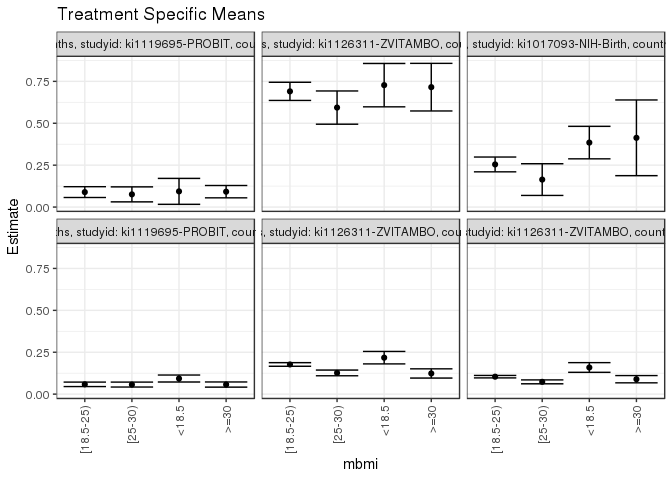

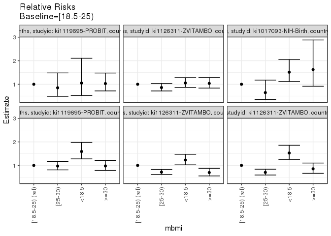

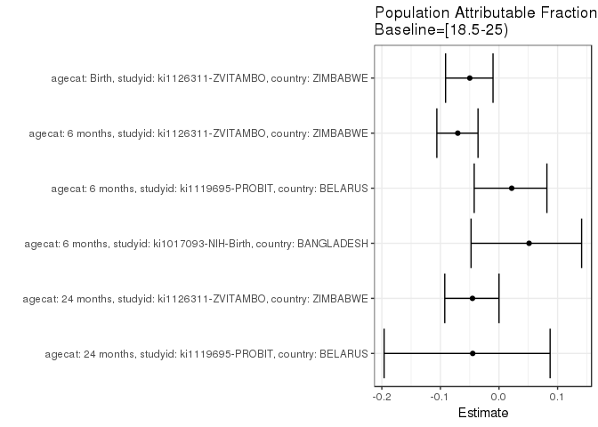

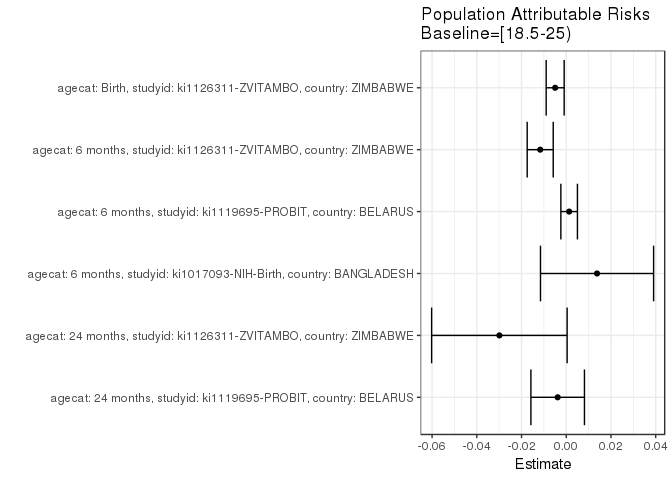

## Results Table

### Parameter: TSM

| agecat | studyid | country | intervention_level | baseline_level | estimate | ci_lower | ci_upper |
| --- | --- | --- | --- | --- | --- | --- | --- |
| Birth | ki1126311-ZVITAMBO | ZIMBABWE | [18.5-25) | NA | 0.1041859 | 0.0968091 | 0.1115628 |
| Birth | ki1126311-ZVITAMBO | ZIMBABWE | <18.5 | NA | 0.1591358 | 0.1301771 | 0.1880946 |
| Birth | ki1126311-ZVITAMBO | ZIMBABWE | [25-30) | NA | 0.0734007 | 0.0617299 | 0.0850715 |
| Birth | ki1126311-ZVITAMBO | ZIMBABWE | >=30 | NA | 0.0891026 | 0.0674501 | 0.1107552 |
| 6 months | ki1017093-NIH-Birth | BANGLADESH | [18.5-25) | NA | 0.2543853 | 0.2102769 | 0.2984938 |
| 6 months | ki1017093-NIH-Birth | BANGLADESH | <18.5 | NA | 0.3847277 | 0.2877948 | 0.4816606 |
| 6 months | ki1017093-NIH-Birth | BANGLADESH | [25-30) | NA | 0.1639823 | 0.0693825 | 0.2585821 |
| 6 months | ki1017093-NIH-Birth | BANGLADESH | >=30 | NA | 0.4131226 | 0.1873171 | 0.6389281 |
| 6 months | ki1119695-PROBIT | BELARUS | [18.5-25) | NA | 0.0585780 | 0.0452487 | 0.0719073 |
| 6 months | ki1119695-PROBIT | BELARUS | <18.5 | NA | 0.0931927 | 0.0724349 | 0.1139506 |
| 6 months | ki1119695-PROBIT | BELARUS | [25-30) | NA | 0.0570457 | 0.0423578 | 0.0717336 |
| 6 months | ki1119695-PROBIT | BELARUS | >=30 | NA | 0.0572329 | 0.0417810 | 0.0726848 |
| 6 months | ki1126311-ZVITAMBO | ZIMBABWE | [18.5-25) | NA | 0.1770679 | 0.1663309 | 0.1878049 |
| 6 months | ki1126311-ZVITAMBO | ZIMBABWE | <18.5 | NA | 0.2175817 | 0.1803783 | 0.2547851 |
| 6 months | ki1126311-ZVITAMBO | ZIMBABWE | [25-30) | NA | 0.1266997 | 0.1097133 | 0.1436861 |
| 6 months | ki1126311-ZVITAMBO | ZIMBABWE | >=30 | NA | 0.1234289 | 0.0959682 | 0.1508897 |
| 24 months | ki1119695-PROBIT | BELARUS | [18.5-25) | NA | 0.0892261 | 0.0570491 | 0.1214032 |
| 24 months | ki1119695-PROBIT | BELARUS | <18.5 | NA | 0.0936283 | 0.0162659 | 0.1709907 |
| 24 months | ki1119695-PROBIT | BELARUS | [25-30) | NA | 0.0757636 | 0.0309738 | 0.1205533 |
| 24 months | ki1119695-PROBIT | BELARUS | >=30 | NA | 0.0918505 | 0.0550209 | 0.1286801 |
| 24 months | ki1126311-ZVITAMBO | ZIMBABWE | [18.5-25) | NA | 0.6903803 | 0.6361410 | 0.7446195 |
| 24 months | ki1126311-ZVITAMBO | ZIMBABWE | <18.5 | NA | 0.7275047 | 0.5981099 | 0.8568994 |
| 24 months | ki1126311-ZVITAMBO | ZIMBABWE | [25-30) | NA | 0.5936197 | 0.4944808 | 0.6927587 |
| 24 months | ki1126311-ZVITAMBO | ZIMBABWE | >=30 | NA | 0.7155058 | 0.5734808 | 0.8575307 |

### Parameter: E(Y)

| agecat | studyid | country | intervention_level | baseline_level | estimate | ci_lower | ci_upper |
| --- | --- | --- | --- | --- | --- | --- | --- |
| Birth | ki1126311-ZVITAMBO | ZIMBABWE | NA | NA | 0.0992319 | 0.0932615 | 0.1052022 |
| 6 months | ki1017093-NIH-Birth | BANGLADESH | NA | NA | 0.2681564 | 0.2306532 | 0.3056597 |
| 6 months | ki1119695-PROBIT | BELARUS | NA | NA | 0.0598756 | 0.0470544 | 0.0726968 |
| 6 months | ki1126311-ZVITAMBO | ZIMBABWE | NA | NA | 0.1654241 | 0.1567862 | 0.1740620 |
| 24 months | ki1119695-PROBIT | BELARUS | NA | NA | 0.0853933 | 0.0554084 | 0.1153781 |
| 24 months | ki1126311-ZVITAMBO | ZIMBABWE | NA | NA | 0.6604775 | 0.6126125 | 0.7083424 |

### Parameter: RR

| agecat | studyid | country | intervention_level | baseline_level | estimate | ci_lower | ci_upper |
| --- | --- | --- | --- | --- | --- | --- | --- |
| Birth | ki1126311-ZVITAMBO | ZIMBABWE | [18.5-25) | [18.5-25) | 1.0000000 | 1.0000000 | 1.0000000 |
| Birth | ki1126311-ZVITAMBO | ZIMBABWE | <18.5 | [18.5-25) | 1.5274210 | 1.2565208 | 1.8567261 |
| Birth | ki1126311-ZVITAMBO | ZIMBABWE | [25-30) | [18.5-25) | 0.7045162 | 0.5919883 | 0.8384340 |
| Birth | ki1126311-ZVITAMBO | ZIMBABWE | >=30 | [18.5-25) | 0.8552268 | 0.6640042 | 1.1015184 |
| 6 months | ki1017093-NIH-Birth | BANGLADESH | [18.5-25) | [18.5-25) | 1.0000000 | 1.0000000 | 1.0000000 |
| 6 months | ki1017093-NIH-Birth | BANGLADESH | <18.5 | [18.5-25) | 1.5123815 | 1.1139587 | 2.0533058 |
| 6 months | ki1017093-NIH-Birth | BANGLADESH | [25-30) | [18.5-25) | 0.6446216 | 0.3529312 | 1.1773883 |
| 6 months | ki1017093-NIH-Birth | BANGLADESH | >=30 | [18.5-25) | 1.6240031 | 0.9153685 | 2.8812285 |
| 6 months | ki1119695-PROBIT | BELARUS | [18.5-25) | [18.5-25) | 1.0000000 | 1.0000000 | 1.0000000 |
| 6 months | ki1119695-PROBIT | BELARUS | <18.5 | [18.5-25) | 1.5909173 | 1.2788301 | 1.9791667 |
| 6 months | ki1119695-PROBIT | BELARUS | [25-30) | [18.5-25) | 0.9738417 | 0.8106585 | 1.1698733 |
| 6 months | ki1119695-PROBIT | BELARUS | >=30 | [18.5-25) | 0.9770379 | 0.7875239 | 1.2121575 |
| 6 months | ki1126311-ZVITAMBO | ZIMBABWE | [18.5-25) | [18.5-25) | 1.0000000 | 1.0000000 | 1.0000000 |
| 6 months | ki1126311-ZVITAMBO | ZIMBABWE | <18.5 | [18.5-25) | 1.2288035 | 1.0249822 | 1.4731554 |
| 6 months | ki1126311-ZVITAMBO | ZIMBABWE | [25-30) | [18.5-25) | 0.7155430 | 0.6176888 | 0.8288994 |
| 6 months | ki1126311-ZVITAMBO | ZIMBABWE | >=30 | [18.5-25) | 0.6970712 | 0.5535420 | 0.8778163 |
| 24 months | ki1119695-PROBIT | BELARUS | [18.5-25) | [18.5-25) | 1.0000000 | 1.0000000 | 1.0000000 |
| 24 months | ki1119695-PROBIT | BELARUS | <18.5 | [18.5-25) | 1.0493373 | 0.5231373 | 2.1048181 |
| 24 months | ki1119695-PROBIT | BELARUS | [25-30) | [18.5-25) | 0.8491184 | 0.4869935 | 1.4805168 |
| 24 months | ki1119695-PROBIT | BELARUS | >=30 | [18.5-25) | 1.0294122 | 0.7177215 | 1.4764634 |
| 24 months | ki1126311-ZVITAMBO | ZIMBABWE | [18.5-25) | [18.5-25) | 1.0000000 | 1.0000000 | 1.0000000 |
| 24 months | ki1126311-ZVITAMBO | ZIMBABWE | <18.5 | [18.5-25) | 1.0537738 | 0.8677926 | 1.2796136 |
| 24 months | ki1126311-ZVITAMBO | ZIMBABWE | [25-30) | [18.5-25) | 0.8598446 | 0.7151929 | 1.0337528 |
| 24 months | ki1126311-ZVITAMBO | ZIMBABWE | >=30 | [18.5-25) | 1.0363937 | 0.8373859 | 1.2826963 |

### Parameter: PAR

| agecat | studyid | country | intervention_level | baseline_level | estimate | ci_lower | ci_upper |
| --- | --- | --- | --- | --- | --- | --- | --- |
| Birth | ki1126311-ZVITAMBO | ZIMBABWE | [18.5-25) | NA | -0.0049541 | -0.0089767 | -0.0009315 |
| 6 months | ki1017093-NIH-Birth | BANGLADESH | [18.5-25) | NA | 0.0137711 | -0.0115159 | 0.0390580 |
| 6 months | ki1119695-PROBIT | BELARUS | [18.5-25) | NA | 0.0012976 | -0.0024062 | 0.0050015 |
| 6 months | ki1126311-ZVITAMBO | ZIMBABWE | [18.5-25) | NA | -0.0116438 | -0.0174668 | -0.0058208 |
| 24 months | ki1119695-PROBIT | BELARUS | [18.5-25) | NA | -0.0038329 | -0.0158066 | 0.0081408 |
| 24 months | ki1126311-ZVITAMBO | ZIMBABWE | [18.5-25) | NA | -0.0299028 | -0.0601949 | 0.0003893 |

### Parameter: PAF

| agecat | studyid | country | intervention_level | baseline_level | estimate | ci_lower | ci_upper |
| --- | --- | --- | --- | --- | --- | --- | --- |
| Birth | ki1126311-ZVITAMBO | ZIMBABWE | [18.5-25) | NA | -0.0499241 | -0.0912014 | -0.0102081 |
| 6 months | ki1017093-NIH-Birth | BANGLADESH | [18.5-25) | NA | 0.0513546 | -0.0476730 | 0.1410220 |
| 6 months | ki1119695-PROBIT | BELARUS | [18.5-25) | NA | 0.0216724 | -0.0423467 | 0.0817595 |
| 6 months | ki1126311-ZVITAMBO | ZIMBABWE | [18.5-25) | NA | -0.0703877 | -0.1061162 | -0.0358132 |
| 24 months | ki1119695-PROBIT | BELARUS | [18.5-25) | NA | -0.0448850 | -0.1961342 | 0.0872390 |
| 24 months | ki1126311-ZVITAMBO | ZIMBABWE | [18.5-25) | NA | -0.0452746 | -0.0925957 | -0.0000030 |